# Effects of Loan Characterics on Borrower's APR: Slide Deck

by Austin

## Investigation Overview

In this presentation. Many visualizations on loans's characterics will be created to study their relationship on borrowers's APR. The main characterics are BorrowerAPR, ProsperScore, AvailableBankcardCredit and CreditScoreRangeUpper.

## Dataset Overview

The Dataset contains 113,917 loans, each row has infomation on the borrow's APR, status, borrowed amount, debt, etc. Variables with many missing values were dropped to make the Dataset more accurate. Outliers were also removed to provide more reliable Data. This study will be analyzing factors that could inflence borrow's APR and which loans were taken by what type of borrowers.

### Distribution of BorrowerAPR

Observe the counts for all BorrowerAPR values, the lowerest APR is at around 0.05% and the highested is at around 0.41%. Two high counts are found at 0.35797% and 0.35643%

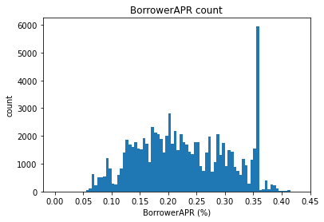

### BorrowerAPR vs. ProsperScore

A PerosperScore was given to each borrowers. The higher the score, the better rating the borrower were received. The plot shows the negative correlation between BorrowerAPR and ProsperScore. The plot explain the higher the APR, the lower the ProsperScore is. This makes sense because borrowers with higher rating tend to received lower interest rate and APR.

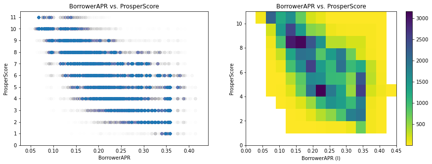

### BorrowerAPR vs ProsperScore on each ProsperRatings

This visualization helps to analyze BorrowerAPR vs ProsperScore on different letter ratings. The patterns shows the lowerest rating(HR) of borrowers have the highest APR percentage, and borrowers with high rating (AA) has the lowers APR percentage. This visualization differentiate groups of people in terms of APR received.

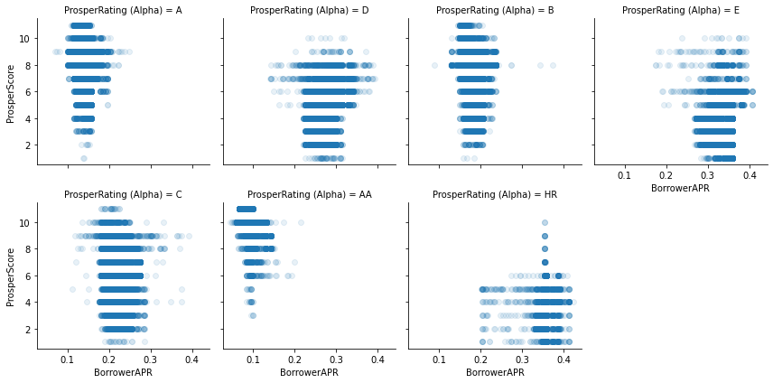